# GEOG-533 Lab 7

Deborah Gabay

Complete the following exercises in Chapter 8 (Introduction to Regression Analysis) of the textbook [R] pages 247-250.

## Question 1

This is Exercise 1 in Chapter 8 of the Textbook [R]. (15 pt.)

A regression of weekly shopping trip frequency on annual income (data entered in thousands of dollars) is performed on data collected from 24 respondents. The results are summarized below:

- Intercept: 0.46
- Slope: 0.19

|  | Sum of squares | Degrees of freedom | Mean square | *F* |
| --- | --- | --- | --- | --- |
| Regression |  |  |  |  |
| Residual | 1.7 |  |  |  |
| Total | 2.3 |  |  |  |

### Question 1(a)

Fill in the blanks in the ANOVA table.

```r
N <- 24
SumSquaresResidual <- 1.7
SumSquaresTotal <- 2.3
SumSquaresRegression <- SumSquaresTotal - SumSquaresResidual
Df_Residual <- 1
Df_Total <- N - 1
Df_Regression <- Df_Total - Df_Residual
MeanSquareRegression <- SumSquaresRegression / Df_Regression
MeanSquareResidual <- SumSquaresResidual / Df_Residual
F <- MeanSquareRegression / MeanSquareResidual
```

|  | Sum of squares | Degrees of freedom | Mean square | *F* |
| --- | --- | --- | --- | --- |
| Regression | 0.6 | 22 | 0.0272727 | 0.0160428 |
| Residual | 1.7 | 1 | 1.7 |  |
| Total | 2.3 | 23 |  |  |

### Question 1(b)

What is the predicted number of weekly shopping trips for someone making $50,000/year?

```r
Intercept <- 0.46
Slope <- 0.19
Number_Weekly_Shopping_Trips <- Intercept + (Slope * 50)
Number_Weekly_Shopping_Trips
```

```
[1] 9.96
```

```r
## The predicted number of weekly shopping trips for someone making $50,000 a year is 9.96, or 10 if you round up
```

### Question 1(c)

In words, what is the meaning of the coefficient 0.19?

A person goes on 0.19 shopping trips for every $1,000 they make.

### Question 1(d)

Is the regression coefficient significantly different from zero? How do you know?

```r
F.value <- MeanSquareRegression / MeanSquareResidual
F.value
```

```
[1] 0.01604278
```

```r
F.critical <- qf(0.95, df1 = 1, df2 = n - 2)
F.critical
```

[output not shown]

```r
## The regression coefficient is not significantly different from zero because the f value is less than the f critical
```

### Question 1(e)

What is the value of the correlation coefficient?

```r
Correlation_Coefficient <- SumSquaresRegression / SumSquaresTotal
Correlation_Coefficient
```

```
[1] 0.2608696
```

```r
## The correlation coefficient is 0.2608696
```

## Question 2

This is Exercise 6 in Chapter 8 of the Textbook [R]. (15 pt.)

The following data are collected in an effort to determine whether snowfall is dependent upon elevation:

| Snowfall (inches) | Elevation (feet) |
| --- | --- |
| 36 | 400 |
| 78 | 800 |
| 11 | 200 |
| 45 | 675 |

Using R, show your work on exercises (a) through (g).

### Question 2(a)

Find the regression coefficients (the intercept and the slope coefficient).

```r
Snowfall <- c(36,78,11,45)
Elevation <- c(400,800,200,675)
df <- data.frame(Snowfall,Elevation)
x <- df$Snowfall
y <- df$Elevation
m <- lm(y~x)
m
```

```
Call:
lm(formula = y ~ x)

Coefficients:
(Intercept)            x
    127.412        9.208
```

```r
intercept <- 127.412
Mean_Snowfall <- mean(x)
Mean_Elevation <- mean(y)
Sd_Snowfall <- sd(x)
Sd_Elevation <- sd(y)
numerator <- sum((x - Mean_Snowfall)*(y - Mean_Elevation))
numerator
```

```
[1] 21187.5
```

```r
denominator <- sum((x - Mean_Snowfall)^2)
denominator
```

```
[1] 2301
```

```r
slope <- numerator / denominator
slope
```

```
[1] 9.207953
```

```r
## The intercept is 127.412 and the slope is about 9.208
```

### Question 2(b)

Estimate the standard error of the residuals about the regression line.

```r
summary(m)
```

```
Call:
lm(formula = y ~ x)

Residuals:
     1      2      3      4
-58.90 -45.63 -28.70 133.23

Coefficients:
            Estimate Std. Error t value Pr(>|t|)
(Intercept)  127.412    111.735   1.140   0.3723
x              9.208      2.290   4.022   0.0566

(Intercept)
x           .
---
Signif. codes:
0 ‘***’ 0.001 ‘**’ 0.01 ‘*’ 0.05 ‘.’ 0.1 ‘ ’ 1

Residual standard error: 109.8 on 2 degrees of freedom
Multiple R-squared:  0.8899,    Adjusted R-squared:  0.8349
F-statistic: 16.17 on 1 and 2 DF,  p-value: 0.05663
```

```r
## The standard error of the residuals about the regression line is 109.8 on 2 degrees of freedom
```

### Question 2(c)

Test the hypothesis that the regression coefficient associated with the independent variables is equal to zero. Also place a 95% confidence interval on the regression coefficient.

```r
Mean_Square_Regression <- sum((fitted(m) - Mean_Elevation)^2)
Mean_Square_Regression
```

```
[1] 195093.5
```

```r
Sum_Squares_Residual <- sum((y - fitted(m))^2)
Sum_Squares_Residual
```

```
[1] 24125.24
```

```r
n <- length(x)
df1 <- 1
df2 <- n - 2
df3 <- df1 + df2
Mean_Square_Residual <- Sum_Squares_Residual / df2
Sum_Squares_Regression <- Mean_Square_Regression / df1
Sum_Squares_Total <- Sum_Squares_Regression + Sum_Squares_Residual
Sum_Squares_Total
```

```
[1] 219218.7
```

```r
Sum_Squares_Residual <- Sum_Squares_Total - Sum_Squares_Regression
F.value <- Mean_Square_Regression / Mean_Square_Residual
F.value
```

```
[1] 16.17339
```

```r
F.critical <- qf(0.95, df1 = 1, df2 = n - 2)
F.critical
```

```
[1] 18.51282
```

```r
if (F.value > F.critical) {
  print("We reject the null hypothesis")
} else {
  print("We cannot reject the null hypothesis")
}
```

```
[1] "We cannot reject the null hypothesis"
```

### Question 2(d)

Find the value of $r^2$.

```r
R_Squared <- Sum_Squares_Regression / Sum_Squares_Total
R_Squared
```

```
[1] 0.889949
```

### Question 2(e)

Make a table of the observed values, predicted values, and the residuals.

```r
Table <- lm(x ~ y,data = df)
summary(Table)
```

```
Call:
lm(formula = x ~ y, data = df)

Residuals:
       1        2        3        4
  4.9772   8.3172  -0.6928 -12.6016

Coefficients:
            Estimate Std. Error t value Pr(>|t|)
(Intercept) -7.63721   13.67764  -0.558   0.6328
y            0.09665    0.02403   4.022   0.0566

(Intercept)
y           .
---
Signif. codes:
0 ‘***’ 0.001 ‘**’ 0.01 ‘*’ 0.05 ‘.’ 0.1 ‘ ’ 1

Residual standard error: 11.25 on 2 degrees of freedom
Multiple R-squared:  0.8899,    Adjusted R-squared:  0.8349
F-statistic: 16.17 on 1 and 2 DF,  p-value: 0.05663
```

### Question 2(f)

Prepare an analysis of variance table portraying the regression results.

|  | Sum of squares | Degrees of freedom | Mean square | *F* |
| --- | --- | --- | --- | --- |
| Regression | 195093.5 | 1 | 195093.5 | 16.173391 |
| Residual | 24125.24 | 2 | 12062.62 |  |
| Total | 219218.7 | 3 |  |  |

### Question 2(g)

Graph the data and the regression line.

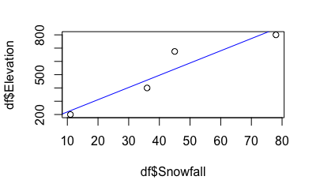

```r
plot(df$Snowfall, df$Elevation)
abline(m, col = "blue")
```

## Question 3

This is Exercise 10 in Chapter 8 of the Textbook [R]. (10 pt.)

Use R and the [Milwaukee dataset](http://spatial.binghamton.edu/geog533/data/Milwaukee_Sales.csv) to:

### Problem

perform a regression using sales price as the dependent variable and lot size as the independent variable.

### Solution

```r
print(Milwaukee_Sales)
```

| Stories | FinSqft | Bedrms | Baths | LotSize | SaleDate | SalePrice | Ald | Age | FullBase | Attic | FIREPLACE | AIR_CONDITIONING | Garage | X | Y |
| --- | --- | --- | --- | --- | --- | --- | --- | --- | --- | --- | --- | --- | --- | --- | --- |
| 1.0 | 1560 | 4 | 1.5 | 4680 | 2012-04 | 61000 | 1 | 76 | 1 | 1 | 0 | 0 | 1 | 2551960 | 405664.0 |
| 1.0 | 1538 | 3 | 1.5 | 7100 | 2012-06 | 85900 | 1 | 65 | 1 | 1 | 1 | 1 | 1 | 2543593 | 416385.2 |
| 1.0 | 1359 | 3 | 1.0 | 5040 | 2012-07 | 87500 | 1 | 72 | 0 | 1 | 0 | 1 | 1 | 2553561 | 412893.6 |
| 1.0 | 1339 | 3 | 2.5 | 5000 | 2012-03 | 89900 | 1 | 70 | 1 | 1 | 0 | 1 | 1 | 2551449 | 408569.1 |
| 1.0 | 1213 | 3 | 1.0 | 5125 | 2012-09 | 64500 | 1 | 61 | 1 | 1 | 0 | 1 | 1 | 2541430 | 412143.4 |
| 1.0 | 1206 | 3 | 1.0 | 5880 | 2012-01 | 35000 | 1 | 72 | 1 | 1 | 0 | 1 | 1 | 2547222 | 412509.6 |
| 1.0 | 1062 | 3 | 1.5 | 7560 | 2012-04 | 74700 | 1 | 71 | 1 | 1 | 0 | 0 | 1 | 2552115 | 410277.9 |
| 1.0 | 1033 | 3 | 1.0 | 5320 | 2012-04 | 71000 | 1 | 67 | 1 | 1 | 0 | 0 | 1 | 2552460 | 404941.9 |
| 2.0 | 1664 | 3 | 2.5 | 7800 | 2012-10 | 127500 | 1 | 63 | 1 | 0 | 1 | 1 | 1 | 2553976 | 414520.8 |
| 2.0 | 1237 | 4 | 1.5 | 5542 | 2012-02 | 73027 | 1 | 42 | 1 | 0 | 0 | 0 | 1 | 2549400 | 405251.3 |

[output cut: 990 more lines]

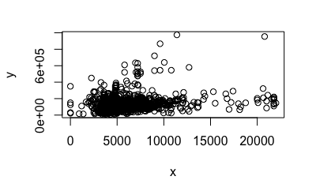

```r
x <- Milwaukee_Sales$LotSize
y <- Milwaukee_Sales$SalePrice
plot(y ~ x)
```

```r
m <- lm(y~x)
m
```

```
Call:
lm(formula = y ~ x)

Coefficients:
(Intercept)            x
  92984.248        6.443
```

```r
summary(m)
```

```
Call:
lm(formula = y ~ x)

Residuals:
    Min      1Q  Median      3Q     Max
-144724  -42205  -14553   20987  808570

Coefficients:
             Estimate Std. Error t value
(Intercept) 9.298e+04  5.249e+03  17.715
x           6.443e+00  7.835e-01   8.223
            Pr(>|t|)
(Intercept)  < 2e-16 ***
x           4.37e-16 ***
---
Signif. codes:
0 ‘***’ 0.001 ‘**’ 0.01 ‘*’ 0.05 ‘.’ 0.1 ‘ ’ 1

Residual standard error: 83090 on 1447 degrees of freedom
Multiple R-squared:  0.04464,   Adjusted R-squared:  0.04398
F-statistic: 67.62 on 1 and 1447 DF,  p-value: 4.374e-16
```

## Question 4

This is Exercise 11 in Chapter 8 of the Textbook [R]. (10 pt.)

Use R and the Hypothetical [UK Housing Prices dataset](http://spatial.binghamton.edu/geog533/data/UK_Housing.csv) to:

### Question 4(a)

perform a regression using house price as the dependent variable, and number of bedrooms as the independent variable;

```r
print(UK_Housing)
```

| region | price | garage | bedrooms | bathrooms | datebuilt | floorarea | detached | fireplace | agelessthan15 | age65andover | nonwhite | unemploy | ownocc | carsperhh | manuf |
| --- | --- | --- | --- | --- | --- | --- | --- | --- | --- | --- | --- | --- | --- | --- | --- |
| 6 | 25500 | 0 | 3 | 2 | 1973 | 70.4 | 0 | 0 | 26.86 | 8.50 | 0.038 | 11.38 | 52.706 | 0.583 | 23.273 |
| 6 | 17450 | 0 | 1 | 1 | 1982 | 40.9 | 0 | 0 | 23.22 | 16.74 | 1.836 | 11.73 | 60.440 | 0.402 | 11.524 |
| 6 | 22450 | 0 | 2 | 1 | 1883 | 78.6 | 0 | 1 | 20.41 | 15.79 | 0.153 | 5.18 | 59.692 | 0.952 | 12.325 |
| 1 | 22500 | 0 | 2 | 1 | 1912 | 81.9 | 0 | 0 | 19.53 | 15.82 | 2.881 | 4.84 | 59.046 | 0.745 | 12.618 |
| 5 | 53500 | 0 | 3 | 1 | 1959 | 83.9 | 0 | 0 | 19.69 | 18.55 | 0.626 | 8.08 | 57.439 | 0.587 | 12.593 |
| 6 | 48100 | 1 | 2 | 1 | 1952 | 104.8 | 0 | 0 | 18.18 | 19.69 | 1.012 | 0.96 | 61.262 | 0.849 | 7.251 |
| 1 | 29250 | 0 | 3 | 1 | 1894 | 136.8 | 0 | 0 | 24.88 | 17.21 | 1.653 | 12.40 | 59.455 | 0.178 | 19.546 |
| 1 | 35450 | 1 | 3 | 1 | 1975 | 65.3 | 0 | 0 | 21.82 | 16.26 | 1.102 | 3.46 | 53.283 | 0.501 | 12.353 |
| 6 | 21500 | 0 | 2 | 2 | 1910 | 95.6 | 0 | 0 | 21.61 | 18.59 | 0.302 | 9.18 | 58.230 | 0.772 | 16.160 |
| 6 | 28250 | 0 | 1 | 1 | 1900 | 76.8 | 0 | 0 | 23.66 | 15.52 | 3.506 | 11.16 | 51.821 | 0.277 | 11.491 |

[output cut: 489 more lines]

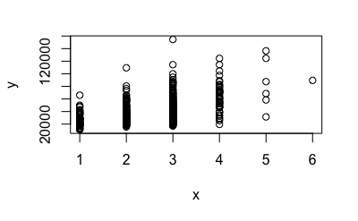

```r
x <- UK_Housing$bedrooms
y <- UK_Housing$price
plot(y ~ x)
```

```r
m <- lm(y~x)
m
```

```
Call:
lm(formula = y ~ x)

Coefficients:
(Intercept)            x
      11254        11893
```

```r
summary(m)
```

```
Call:
lm(formula = y ~ x)

Residuals:
   Min     1Q Median     3Q    Max
-39324 -11511  -3539   8461 107568

Coefficients:
            Estimate Std. Error t value Pr(>|t|)
(Intercept)  11254.1     2312.7   4.866 1.53e-06
x            11892.6      876.5  13.568  < 2e-16

(Intercept) ***
x           ***
---
Signif. codes:
0 ‘***’ 0.001 ‘**’ 0.01 ‘*’ 0.05 ‘.’ 0.1 ‘ ’ 1

Residual standard error: 17800 on 497 degrees of freedom
Multiple R-squared:  0.2703,    Adjusted R-squared:  0.2688
F-statistic: 184.1 on 1 and 497 DF,  p-value: < 2.2e-16
```

### Question 4(b)

repeat part (a), using the number of bathrooms as the independent variable, and comment on the results.

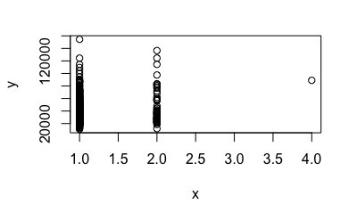

```r
x <- UK_Housing$bathrooms
y <- UK_Housing$price
plot(y ~ x)
```

```r
m <- lm(y~x)
m
```

```
Call:
lm(formula = y ~ x)

Coefficients:
(Intercept)            x
      32729         7113
```

```r
summary(m)
```

```
Call:
lm(formula = y ~ x)

Residuals:
   Min     1Q Median     3Q    Max
-34955 -15242  -5342  10908 114658

Coefficients:
            Estimate Std. Error t value Pr(>|t|)
(Intercept)    32729       3149  10.394  < 2e-16
x               7113       2682   2.653  0.00824

(Intercept) ***
x           **
---
Signif. codes:
0 ‘***’ 0.001 ‘**’ 0.01 ‘*’ 0.05 ‘.’ 0.1 ‘ ’ 1

Residual standard error: 20690 on 497 degrees of freedom
Multiple R-squared:  0.01396,   Adjusted R-squared:  0.01198
F-statistic: 7.036 on 1 and 497 DF,  p-value: 0.008245
```